# Lab assignment: fraud detection through ensemble methods

[figure not shown]

In this assignment we will use all the skills in ensemble learning we acquire from previous exercises to build a an automated fraud detection system.

## Guidelines

Throughout this notebook you will find empty cells that you will need to fill with your own code. Follow the instructions in the notebook and pay special attention to the following symbols.

|  | You will need to solve a question by writing your own code or answer in the cell immediately below, or in a different file as instructed. Both correctness of the solution and code quality will be take… |
| --- | --- |
|  | This is a hint or useful observation that can help you solve this assignment. You are not expected to write any solution, but you should pay attention to them to understand the assignment. |
|  | This is an advanced and voluntary excercise that can help you gain a deeper knowledge into the topic. This exercise won't be taken into account towards marking, but you are encouraged to undertake it.… |

To avoid missing packages and compatibility issues you should run this notebook under one of the [recommended Ensembles environment files](https://github.com/albarji/teaching-environments/tree/master/ensembles).

The following code will embed any plots into the notebook instead of generating a new window:

```python
import pandas as pd
import numpy as np
import math
import matplotlib.pyplot as plt
import seaborn as sns
%matplotlib inline
import warnings
warnings.filterwarnings('ignore')
```

Lastly, if you need any help on the usage of a Python function you can place the writing cursor over its name and press Caps+Shift to produce a pop-out with related documentation. This will only work inside code cells.

Let's go!

## Data loading

The data for this problem is included in the *data* folder, with separate files for training and test data. Each file includes several unidentified explanatory features, together with an "Amount" feature and the target "Class". Fraudulent operations are marked as Class == 1.

|  | Load the training and test data into Pandas DataFrames with names **train** and **test**, respectively. |
| --- | --- |

```python
data = pd.read_csv('./data/fraud_train.csv',header=0, sep=',')
```

|  | Analyze the training data. How many explanatory variables do you have? What is the distribution of classes? |
| --- | --- |

Vemos el tamaño del dataset

```python
data.shape
```

```
(5246, 30)
```

Vemos las primeras líneas para hacernos una idea

```python
data.head()
```

|  | V1 | V2 | V3 | V4 | V5 | V6 | V7 | V8 | V9 | V10 | ... | V21 | V22 | V23 | V24 | V25 | V26 | V27 | V28 | Amount | Class |
| --- | --- | --- | --- | --- | --- | --- | --- | --- | --- | --- | --- | --- | --- | --- | --- | --- | --- | --- | --- | --- | --- |
| 0 | -2.312227 | 1.951992 | -1.609851 | 3.997906 | -0.522188 | -1.426545 | -2.537387 | 1.391657 | -2.770089 | -2.772272 | ... | 0.517232 | -0.035049 | -0.465211 | 0.320198 | 0.044519 | 0.177840 | 0.261145 | -0.143276 | 0.00 | 1 |
| 1 | -3.043541 | -3.157307 | 1.088463 | 2.288644 | 1.359805 | -1.064823 | 0.325574 | -0.067794 | -0.270953 | -0.838587 | ... | 0.661696 | 0.435477 | 1.375966 | -0.293803 | 0.279798 | -0.145362 | -0.252773 | 0.035764 | 529.00 | 1 |
| 2 | -2.303350 | 1.759247 | -0.359745 | 2.330243 | -0.821628 | -0.075788 | 0.562320 | -0.399147 | -0.238253 | -1.525412 | ... | -0.294166 | -0.932391 | 0.172726 | -0.087330 | -0.156114 | -0.542628 | 0.039566 | -0.153029 | 239.93 | 1 |
| 3 | -4.397974 | 1.358367 | -2.592844 | 2.679787 | -1.128131 | -1.706536 | -3.496197 | -0.248778 | -0.247768 | -4.801637 | ... | 0.573574 | 0.176968 | -0.436207 | -0.053502 | 0.252405 | -0.657488 | -0.827136 | 0.849573 | 59.00 | 1 |
| 4 | 1.234235 | 3.019740 | -4.304597 | 4.732795 | 3.624201 | -1.357746 | 1.713445 | -0.496358 | -1.282858 | -2.447469 | ... | -0.379068 | -0.704181 | -0.656805 | -1.632653 | 1.488901 | 0.566797 | -0.010016 | 0.146793 | 1.00 | 1 |

5 rows × 30 columns

### Variable objetivo

Cambiamos de nombre a la variable objetivo, *Class*, por *target* y obtenemos sus valores.

```python
data.columns= list(data.columns.str.replace('Class','target'))
```

```python
data.target.unique()
```

```
array([1, 0], dtype=int64)
```

Cambiamos los valores:

anomalos: 1 por -1

no-anomalos: 0 por 1

ya que es cómo el modelo *isolation* define a los valores.

```python
data.replace({'target': {1:-1}}, inplace=True)
data.replace({'target': {0: 1}}, inplace=True)
```

Chequeamos la distribución de valores de target.

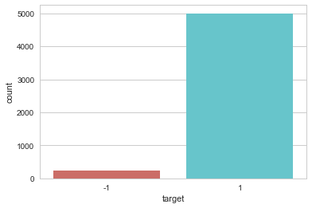

```python
sns.set(style="white")
sns.set(style="whitegrid", color_codes=True)

#draw histogram plot
sns.countplot(x = 'target', data = data, palette = 'hls')
plt.show()
```

Calculamos el porcentage de valores anomalos (contaminación).

```python
len(data[data.target==-1])
```

```
246
```

```python
contamination= len(data[data.target==-1])/len(data)
print('Porcentage de contaminación: {}%'.format(round(contamination*100,1)))
```

```
Porcentage de contaminación: 4.7%
```

### Variables explicativas

#### Missing Values

Comprobamos si hay NAs  
No los hay

```python
assert(data.drop(['target'], axis=1).isna().sum().sum() == 0)
```

#### Estadísticos básicos

```python
data['target']=data['target'].astype('category')
```

```python
list(set(data.dtypes.tolist()))
```

```
[CategoricalDtype(categories=[-1, 1], ordered=False), dtype('float64')]
```

```python
data_numeric = data.select_dtypes(exclude = ['category'])
```

Observando los estadísticos básicos vemos que en alguna variable podría haber outliers. Se comprueba después.

```python
data.describe()
```

|  | V1 | V2 | V3 | V4 | V5 | V6 | V7 | V8 | V9 | V10 | ... | V20 | V21 | V22 | V23 | V24 | V25 | V26 | V27 | V28 | Amount |
| --- | --- | --- | --- | --- | --- | --- | --- | --- | --- | --- | --- | --- | --- | --- | --- | --- | --- | --- | --- | --- | --- |
| count | 5246.000000 | 5246.000000 | 5246.000000 | 5246.000000 | 5246.000000 | 5246.000000 | 5246.000000 | 5246.000000 | 5246.000000 | 5246.000000 | ... | 5246.000000 | 5246.000000 | 5246.000000 | 5246.000000 | 5246.000000 | 5246.000000 | 5246.000000 | 5246.000000 | 5246.000000 | 5246.000000 |
| mean | -0.539993 | 0.182329 | 0.302563 | 0.308565 | -0.470484 | -0.037538 | -0.397722 | 0.131348 | -0.212005 | -0.269800 | ... | 0.054128 | 0.010017 | -0.132105 | -0.051927 | 0.010908 | 0.133937 | 0.019680 | 0.023637 | -0.001524 | 93.582991 |
| std | 2.700370 | 2.111652 | 2.698561 | 1.715353 | 2.036673 | 1.411958 | 2.273415 | 2.027100 | 1.322918 | 1.863553 | ... | 0.712131 | 1.154418 | 0.696071 | 0.748970 | 0.583605 | 0.470548 | 0.491799 | 0.460188 | 0.350230 | 250.696936 |
| min | -34.591213 | -44.639245 | -31.103685 | -5.519697 | -32.092129 | -21.248752 | -21.922811 | -37.353443 | -9.283925 | -18.271168 | ... | -11.748689 | -12.815353 | -8.887017 | -26.751119 | -2.185457 | -7.495741 | -1.345640 | -7.144717 | -8.364853 | 0.000000 |
| 25% | -1.160978 | -0.556885 | 0.070103 | -0.719923 | -0.999000 | -0.734639 | -0.673759 | -0.137595 | -0.803361 | -0.566849 | ... | -0.167872 | -0.227437 | -0.549349 | -0.178857 | -0.332102 | -0.136150 | -0.328017 | -0.061094 | -0.007941 | 5.102500 |
| 50% | -0.341215 | 0.142323 | 0.692239 | 0.214909 | -0.360585 | -0.226545 | -0.100690 | 0.079762 | -0.173325 | -0.116838 | ... | -0.023263 | -0.053649 | -0.103794 | -0.045147 | 0.068361 | 0.168982 | -0.080875 | 0.015344 | 0.023243 | 22.190000 |
| 75% | 1.157161 | 0.867764 | 1.357493 | 1.089141 | 0.211143 | 0.400486 | 0.395594 | 0.401846 | 0.454970 | 0.422938 | ... | 0.179043 | 0.126478 | 0.299756 | 0.087792 | 0.402059 | 0.434307 | 0.289032 | 0.102887 | 0.083911 | 81.665000 |
| max | 1.618082 | 16.713389 | 3.971381 | 11.927512 | 31.457046 | 21.393069 | 34.303177 | 20.007208 | 7.938980 | 11.519106 | ... | 6.993759 | 27.202839 | 4.534454 | 5.303607 | 3.979637 | 2.208209 | 2.964300 | 4.444505 | 5.414028 | 7712.430000 |

8 rows × 29 columns

#### Distribuciones

Echamos un vistazo a las distribuciones:  
Observamos que son casi todas simétricas y centradas en cero.

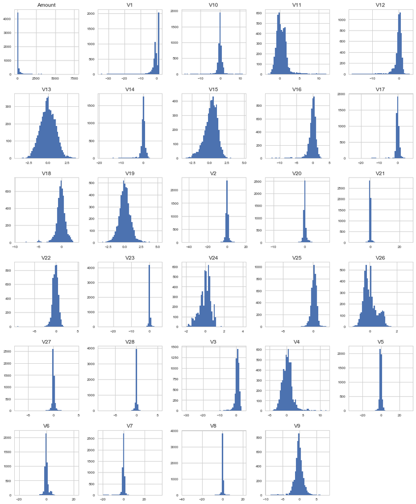

```python
data_numeric.hist(figsize=(16, 20), bins=50, xlabelsize=8, ylabelsize=8);
```

#### Outliers

Ploteamos el boxplot para cada variable  
Observamos que hay outliers. Más adelante comprobaremos su comporotamiento en relaciones n-dim y si realmente son valores anomalos.

Variables 1 a 10

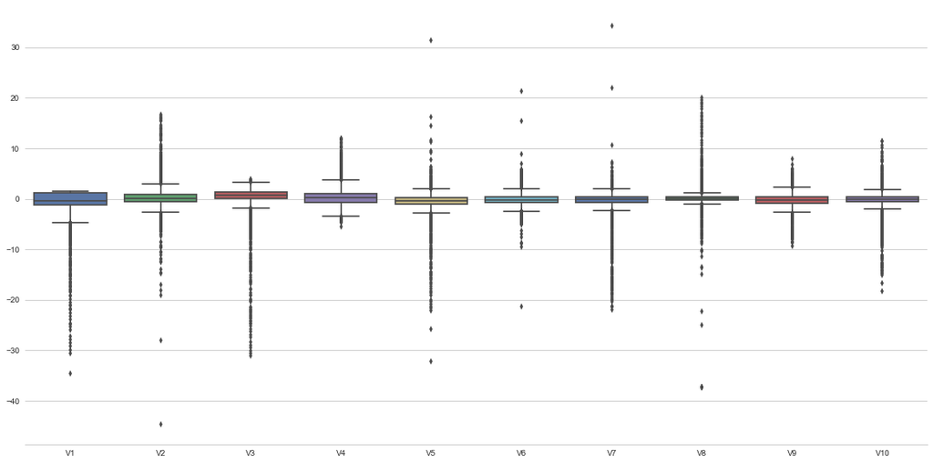

```python
sns.set(rc={'figure.figsize':(20, 10)})
sns.set_style("whitegrid")
sns.boxplot(data=data_numeric.drop('Amount', axis=1).iloc[:,0:10], palette="deep")
sns.despine(left=True)
```

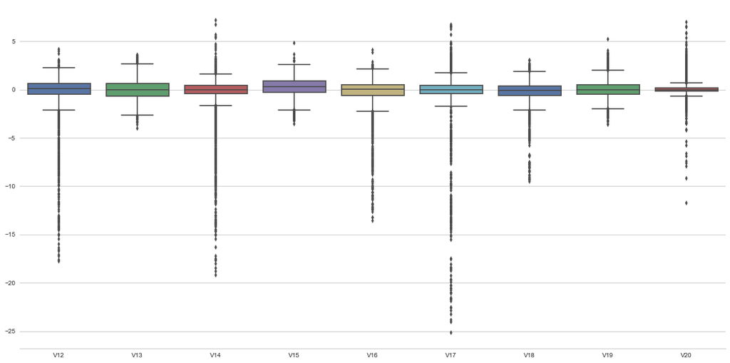

```python
sns.set(rc={'figure.figsize':(20, 10)})
sns.set_style("whitegrid")
sns.boxplot(data=data_numeric.drop('Amount', axis=1).iloc[:,11:20], palette="deep")
sns.despine(left=True)
```

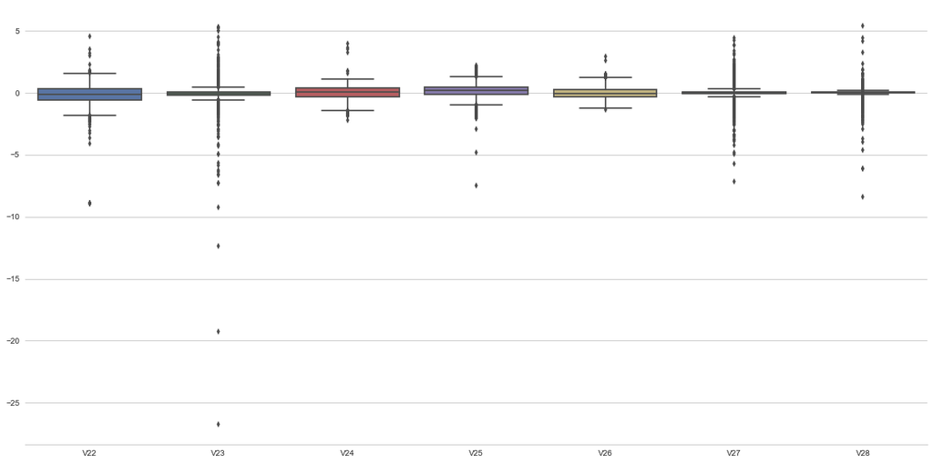

```python
sns.set(rc={'figure.figsize':(20, 10)})
sns.set_style("whitegrid")
sns.boxplot(data=data_numeric.drop('Amount', axis=1).iloc[:,21:], palette="deep")
sns.despine(left=True)
```

Variables Amount

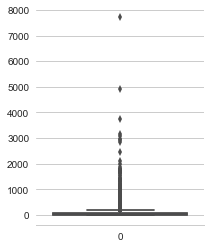

```python
sns.set(rc={'figure.figsize':(3, 4)})
sns.set_style("whitegrid")
sns.boxplot(data=data_numeric['Amount'], palette="deep")
sns.despine(left=True)
```

#### Relación 1-dim de las variables explicativas con el target

Vemos la relación de las explicativas con el target en un scatter plot

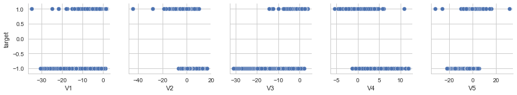

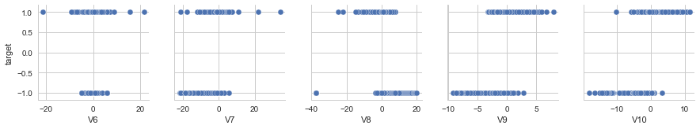

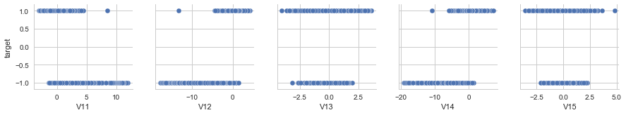

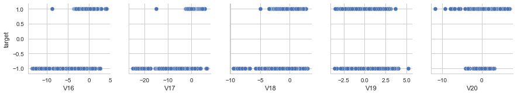

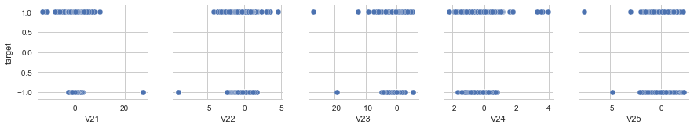

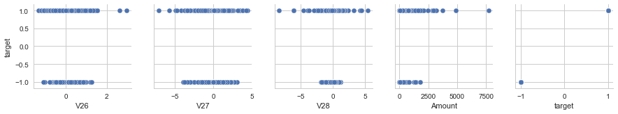

```python
for i in range(0, len(data.columns), 5):
    sns.pairplot(data=data,
                x_vars=data.columns[i:i+5],
                y_vars=['target'])
```

#### Correlaciones

Comprobamos:

Correlaciones de las variables explicativa con target

Matriz de correlaciones de las variables explicativas

Correlaciones de las variables explicativa con target

```python
data['target']=data['target'].astype('int')
data_numeric = data.select_dtypes(exclude = ['category'])
matrix_corr = data_numeric.corr()
df_num_corr = matrix_corr['target'].loc[data_numeric.columns != 'target']
golden_features_list = df_num_corr[abs(df_num_corr) > 0.5].sort_values(ascending=False)
print("There is {} strongly correlated values with target:\n{}".format(len(golden_features_list), golden_features_list))
```

```
There is 9 strongly correlated values with target:
V14    0.777546
V12    0.720151
V17    0.692453
V10    0.665723
V3     0.640011
V16    0.639489
V7     0.567711
V4    -0.561232
V11   -0.589896
Name: target, dtype: float64
```

Matriz de correlaciones de las variables explicativas

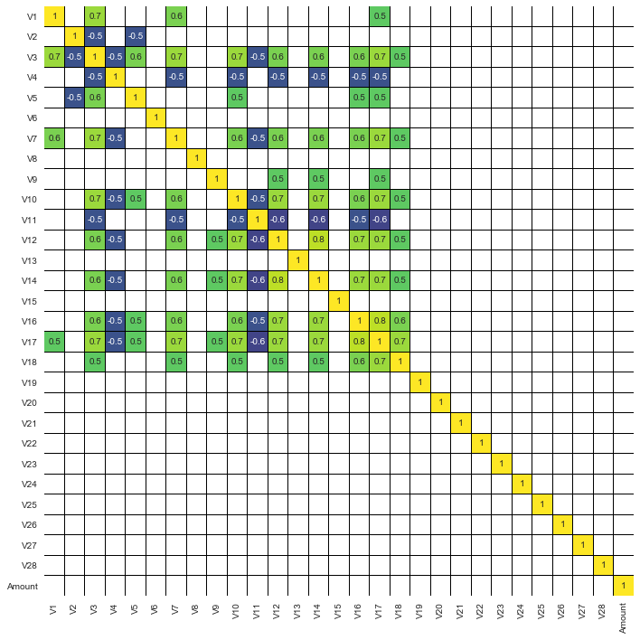

```python
matrix_corr_plot= round(data_numeric.drop('target', axis=1).corr(),1)
plt.figure(figsize=(20, 12))
sns.heatmap(matrix_corr_plot[(matrix_corr_plot >= 0.5) | (matrix_corr_plot <= -0.45)],
            cmap='viridis', vmax=1.0, vmin=-1.0, linewidths=0.01, linecolor='black',
            cbar=False, annot=True, annot_kws={"size": 10}, square=True)
```

## Unsupervised fraud detector

Fraudulent activities are usually prosecuted, therefore fraudsters need to be creative and come up constantly with new ways of performing fraud. Furthermore, frauds are scarce (fortunately), and so we have few positive class patterns available for training. Because of these facts, it might make sense to build an unsupervised fraud detector.

|  | Using **only the training data**, create an anomaly detection model. You should also choose an error metric adequate for the problem, and tune the model parameters in order to optimize this error. |
| --- | --- |

Renombramos el dataset train y lo descomponemos en matriz X e y  
Además, cargamos el test y le damos el mismo tratmiento.

```python
import pandas as pd
import numpy as np
import math
import matplotlib.pyplot as plt
import seaborn as sns
%matplotlib inline
import warnings
warnings.filterwarnings('ignore')
```

```python
data_train = pd.read_csv('./data/fraud_train.csv',header=0, sep=',')
data_test = pd.read_csv('./data/fraud_test.csv',header=0, sep=',')
```

```python
def preprocess_fnc(data, target):
    data.replace({target: {1:-1}}, inplace=True)
    data.replace({target: {0: 1}}, inplace=True)
    #data[target]=data[target].astype('category')

preprocess_fnc(data_train,"Class")
preprocess_fnc(data_test,"Class")
```

```python
def create_Xy(dataset, target):
    bool= dataset.columns != target
    return (dataset.loc[:,bool].values,dataset.loc[:,~bool].values)

X_train,y_train = create_Xy(data_train, 'Class')
X_test,y_test = create_Xy(data_train, 'Class')
```

```python
print('Dimensiones de X_train: ',X_train.shape,'\nDimensiones de y_train: ',y_train.shape,'\n\nDimensiones de X_test: ',X_test.shape,'\nDimensiones de y_test: ',y_test.shape)
```

```
Dimensiones de X_train:  (5246, 29)
Dimensiones de y_train:  (5246, 1)

Dimensiones de X_test:  (5246, 29)
Dimensiones de y_test:  (5246, 1)
```

Metodología:

1. Definición de los modelos.
2. Predicción de los modelos.
3. Selección del mejor modelo
1. Definición de los modelos.

Se trabaja en training set para obtener varios modelos con parámetros distintos.

1. Definición de los parámetros a optimizar en el cross-validation
2. Definición de las métricas con las que optimizar los parámetros
3. Definición del cross-validation
1. Dividisión del train set en k folds
2. Entrenamiento del modelo en k-1 folds y validamos en el sobrante
4. Obteneción de las métricas de performance de cada modelo
2. Predicción de los modelos.

1. Cálculo la predicción de los modelos con el testing set
2. Cálculo el score de las predicciones
3. Predicción de los modelos.
1. Comparamos modelos
2. Matemáticamente
3. Gráficamente

### 1. Definición de los modelos.

#### A. Definimos los parámetros a optimizar en el cross-validation

Los parámetros a optimizar son:

número de arboles del randomForest.

número máximo de observaciones por sample.

número máximo de variables a analizar a la hora de crecer el árbol.

```python
from sklearn.model_selection import ParameterGrid
```

```python
"""param_grid = {
    "n_estimators": [100, 200, 500, 1000],
    "max_samples": ['auto', 16, 32, 64, 128, 256],
    "max_features": [0.1, 0.2, 0.5, 1.0]
}
"""
param_grid = {
    "contamination":[0.01,0.05,0.1],
    "n_estimators": [100, 200],
    "max_samples": ['auto', 16],
    "max_features": [0.1, 0.2]
}
paramgrid_model= ParameterGrid(param_grid)
print('Número de modelos: ',len(ParameterGrid(param_grid)))
```

```
Número de modelos:  24
```

#### B. Definidción de las métricas con las que optimizar los parámetros

Las métricas que optimizan los parámetros son:

F1.

$F1 = \frac{2·precision·recall}{precision + recall}.$

precision: Positive Predictive Value, $\frac{TP}{TP+FP}$.

recall: True Positive Rate, $\frac{TP}{TP+FN}$.

```python
metrics=['f1', 'precision','recall']
```

#### C. Definición del cross-validation

#### a. Dividisión del train set en k folds

Debido a las pocas observaciones anomalas, 4,7%, dividimos en k=3.

```python
from sklearn.model_selection import StratifiedKFold
skf = StratifiedKFold(n_splits=3, random_state=77, shuffle=False)
folds_idx = list(skf.split(X_train,y_train))
```

```python
for i, fold in enumerate(folds_idx):
    print('trainFold'+str(i)+': ', len(fold[0]),'validationFold'+str(i)+': ', len(fold[1]))
```

```
trainFold0:  3497 validationFold0:  1749
trainFold1:  3497 validationFold1:  1749
trainFold2:  3498 validationFold2:  1748
```

#### b. Entrenamiento del modelo en k-1 folds y validamos en el sobrante

```python
from sklearn.ensemble import IsolationForest
from sklearn.metrics import roc_auc_score
from sklearn.metrics import accuracy_score, f1_score, precision_score, recall_score, classification_report, confusion_matrix
```

```python
def CV_fnc(folds, dataset, target, IF):
    f1,precision,recall = [],[],[]
    for i, fold in enumerate(folds):
        X_train= dataset.loc[list(fold[0])].drop(target, axis=1)
        y_train= dataset.loc[list(fold[0])].loc[:,target]
        X_validation= dataset.loc[list(fold[1])].drop(target, axis=1)
        y_validation= dataset.loc[list(fold[1])].loc[:,target]
        IF.fit(X_train)
        y_validation_pred= IF.predict(X_validation)
        f1.append(f1_score(y_validation, y_validation_pred, pos_label=-1, average="binary"))
        precision.append(precision_score(y_validation, y_validation_pred, pos_label=-1, average="binary"))
        recall.append(recall_score(y_validation, y_validation_pred, pos_label=-1, average="binary"))

    f1= np.mean(f1)
    precision= np.mean(precision)
    recall= np.mean(recall)
    return (f1,precision,recall)
```

#### Obteneción de las métricas de performance de cada modelo

```python
folds= folds_idx
dataset= data_train
target= 'Class'
for i in range(len(paramgrid_model)):
    # Iteramos sobre la i para poder pasar los parametros al modelo Isolation.
    # Isoltaion no lee objetos de paramgrid de golpe así que se los pasamos uno a uno.
    IF = IsolationForest(n_estimators=ParameterGrid(param_grid)[i]['n_estimators'],
                         max_samples=ParameterGrid(param_grid)[i]['max_samples'],
                         contamination=ParameterGrid(param_grid)[i]['contamination'],
                         max_features=ParameterGrid(param_grid)[i]['max_features'])
    IFmetrics=CV_fnc(folds, dataset, target, IF)
    try:
        performance.loc[i]= [IFmetrics[0],IFmetrics[1],IFmetrics[2]]
    except:
        performance= pd.DataFrame([[IFmetrics[0],IFmetrics[1],IFmetrics[2]]],
                                  columns=['f1','precision','recall'],
                                  index=[i]
                                  )
```

Comprobamos qué métrica nos arroja una mejor confusion matrix.  
Una confussion matrix adecuada es tal que el número de False Positive (FP) sea el menor posible sin descuidar el False Negative (FN) que sería el lado conservador.  
Tiene que ser un trade-off entre FP (prioritario) y FN.  
Por tanto, comprobamos los modelos que mejor métrica han obtenido en el data train para cada una de ellas y calculamos su mariz de confusión.  
Si ninguna de ellas nos satifaciera, podríamos creamos una métrica que combinara ambas.

**precision**: Positive Predictive Value, $\frac{TP}{TP+FP}$.  
Si $TP >> FP \to precision = 1$  
Si $FP >> TP \to precision = 0$

**recall**: True Positive Rate, $\frac{TP}{TP+FN}$.  
Si $TP >> FN \to recall = 1$  
Si $FN >> TP \to recall = 0$

**F1**: True Positive Rate, $\frac{2·precision·recall}{precision + recall}$  
Si alguna de las 2 métricas se hiciera 0 (peor caso) F1 sería 0 $\to$ Cuanto mayor F1, mejor.

```python
IF_F1_selected = performance['f1'].idxmax()
IF_F1_selected
```

```
11
```

```python
performance.loc[performance['f1'].idxmax()]
```

```
f1           0.715114
precision    0.681197
recall       0.756098
Name: 11, dtype: float64
```

```python
IF_precission_selected = performance['precision'].idxmax()
IF_precission_selected
```

```
11
```

```python
performance.loc[performance['precision'].idxmax()]
```

```
f1           0.715114
precision    0.681197
recall       0.756098
Name: 11, dtype: float64
```

```python
IF_recall_selected = performance['recall'].idxmax()
IF_recall_selected
```

```
17
```

```python
performance.loc[performance['recall'].idxmax()]
```

```
f1           0.559216
precision    0.414383
recall       0.861789
Name: 17, dtype: float64
```

```python
from sklearn.metrics import confusion_matrix
```

```python
def performance_metric_fnc(model_selected, metric):
    IF = IsolationForest(n_estimators=ParameterGrid(param_grid)[model_selected]['n_estimators'],
                         max_samples=ParameterGrid(param_grid)[model_selected]['max_samples'],
                         contamination=ParameterGrid(param_grid)[model_selected]['contamination'],
                         max_features=ParameterGrid(param_grid)[model_selected]['max_features'])
    IF.fit(X_train)
    y_test_pred= IF.predict(X_test)
    if metric == 'f1':
        performance_metric= f1_score(y_test, y_test_pred, average="binary")
    elif metric == 'precision':
        performance_metric= precision_score(y_test, y_test_pred, average="binary")
    elif metric == 'recall':
        performance_metric= recall_score(y_test, y_test_pred, average="binary")
    CM= confusion_matrix(y_test, y_test_pred, labels=[-1,1], sample_weight=None)
    tn, fn, fp, tp = CM.ravel()

    return pd.DataFrame([[model_selected,performance_metric,tn, fn, fp, tp]],columns=['model','performance_test','TP','FP','FN','TN'],index=[metric])
```

```python
from sklearn.metrics import confusion_matrix
performance_test= None
for metric in metrics:
    model_selected = performance[metric].idxmax()
    try:
        performance_test= performance_test.append(performance_metric_fnc(model_selected, metric))
    except:
        performance_test= performance_metric_fnc(model_selected, metric)
```

```python
performance_test
```

|  | model | performance_test | TP | FP | FN | TN |
| --- | --- | --- | --- | --- | --- | --- |
| f1 | 11 | 0.987679 | 193 | 53 | 70 | 4930 |
| precision | 11 | 0.986554 | 179 | 67 | 84 | 4916 |
| recall | 17 | 0.937400 | 212 | 34 | 313 | 4687 |

```python
def print_CM(data, metric):
    print("Matriz de confusión para la métrica:",metric,"\n")
    return pd.DataFrame(np.array(data.loc[metric][2:]).reshape(2,2), columns=['Pred_anomalia','Pred_regular'], index=['Real_anomalia','Real_regular'])
```

```python
metric= metrics[0]
print_CM(performance_test, metric)
```

```
Matriz de confusión para la métrica: f1
```

|  | Pred_anomalia | Pred_regular |
| --- | --- | --- |
| Real_anomalia | 193.0 | 53.0 |
| Real_regular | 70.0 | 4930.0 |

```python
metric= metrics[1]
print_CM(performance_test, metric)
```

```
Matriz de confusión para la métrica: precision
```

|  | Pred_anomalia | Pred_regular |
| --- | --- | --- |
| Real_anomalia | 179.0 | 67.0 |
| Real_regular | 84.0 | 4916.0 |

```python
metric= metrics[2]
print_CM(performance_test, metric)
```

```
Matriz de confusión para la métrica: recall
```

|  | Pred_anomalia | Pred_regular |
| --- | --- | --- |
| Real_anomalia | 212.0 | 34.0 |
| Real_regular | 313.0 | 4687.0 |

## **Conclusión**

Por tanto, el **modelo Isolation Forest seleccionado** es:

```python
paramgrid_model[int(performance_test.loc['f1'][0])]
```

```
{'n_estimators': 200,
 'max_samples': 16,
 'max_features': 0.1,
 'contamination': 0.05}
```

|  | Create a visualization showing the performance of this model over the test data. |
| --- | --- |

```python
performance_test.sort_values(by=['performance_test'], ascending=0, inplace=True)
```

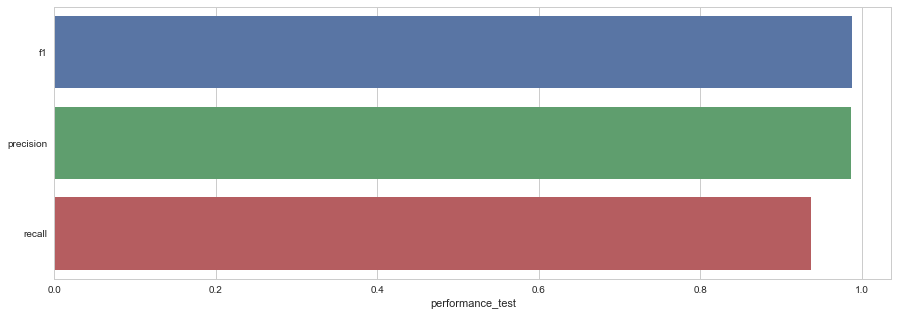

```python
plt.figure(figsize=(15,5))
sns.barplot(y=performance_test.index, x="performance_test", data=performance_test)
```

## Supervised model

|  | Let's check now whether we can improve the results using a supervised model, that is, a model that exploits the Class information available in the training data. Build an ensemble-based classification… |
| --- | --- |

Se probarán las siguientes estrategías:

### _1. Naïve

Establecemos como benchmark el modelo Naïve ya que es el modelo más laxo.

```python
from sklearn.naive_bayes import GaussianNB
gnb = GaussianNB()
y_test_pred = gnb.fit(X_train, y_train).predict(X_test)
from sklearn.metrics import f1_score, recall_score
f1_score_gnb= f1_score(y_test, y_test_pred,pos_label=-1, average='binary')
```

```python
res_df_Aux= pd.DataFrame.from_dict({"model": ["Naive"],
                                    "performance": f1_score_gnb
                                    })
try:
    res_df= pd.concat([res_df,res_df_Aux], axis=0)
except:
    res_df= res_df_Aux
res_df
```

|  | model | performance |
| --- | --- | --- |
| 0 | Naive | 0.716007 |

### _2. Esemble de árboles

Calculamos el performance de los esembles básicos RandomForest, Adaboost y GradientBoosting  
Mediante *GridSearchCV()* realizamos un cross-validation de los distintos modelos propuestos  
Los modelos son:

```python
from sklearn.ensemble import AdaBoostClassifier, RandomForestClassifier, GradientBoostingClassifier
from sklearn.model_selection import RandomizedSearchCV, GridSearchCV, ParameterGrid
from sklearn.metrics import make_scorer, f1_score
from sklearn.linear_model import LogisticRegression
from sklearn.neighbors import KNeighborsClassifier
from sklearn.naive_bayes import GaussianNB
from mlxtend.classifier import StackingCVClassifier
```

```python
def trainscore(Xtrain, ytrain, Xtest, ytest, estimator):
    """Trains an estimator and returns score over a test set"""
    estimator.fit(Xtrain, ytrain)
    return (estimator.score(Xtest, ytest) * 100, estimator.best_estimator_, estimator.cv_results_, estimator.best_params_)

def tune(Xtrain, ytrain, Xtest, ytest, estimator, param_dist, n_iter_search, n_jobs):
    """Performs hyperparameter tuning over an estimator"""
    try:
        search = RandomizedSearchCV(estimator, param_distributions=param_dist, n_iter=n_iter_search, n_jobs=n_jobs, scoring= make_scorer(f1_score, greater_is_better = True, average='binary'))
        return trainscore(Xtrain, ytrain, Xtest, ytest, search)
    except ValueError:
        search = GridSearchCV(estimator, param_grid=param_dist, n_jobs=n_jobs, scoring= make_scorer(f1_score, greater_is_better = True, average='binary'))
        return trainscore(Xtrain, ytrain, Xtest, ytest, search)

ntrees = 50

models = {
    "randomForest": {
        "class" : RandomForestClassifier(),
        "param_dist" : {
            "n_estimators" : [ntrees],
            "max_depth": [3, 5, 15, 25, None],
            "max_features": ["sqrt", "log2", None],
            "min_samples_split": [2, 4, 8, 16, 32],
            "min_samples_leaf": [1, 2, 4, 8, 16, 32],
            "bootstrap": [True, False],
            "criterion": ["gini", "entropy"]
        }
    },
    "boosting": {
        "class" : AdaBoostClassifier(),
        "param_dist" : {
            "n_estimators" : [ntrees],
            "learning_rate": np.logspace(-5,0,12)
        }
    },
    "gradientBoosting": {
        "class" : GradientBoostingClassifier(),
        "param_dist" : {
            "n_estimators" : [ntrees],
            "loss": ["deviance", "exponential"],
            "learning_rate": np.logspace(-5,0,12),
            "max_depth": [3, 5, 15, 25, None],
            "min_samples_split": [2, 4, 8, 16, 32],
            "min_samples_leaf": [1, 2, 4, 8, 16, 32],
            "subsample" : [0.1, 0.2, 0.5, 0.9, 1],
            "max_features": ["sqrt", "log2", None],
        }
    }
}

n_jobs = 7
n_iter_search = 50


aux = {
    modelname : tune(
        X_train, y_train, X_test, y_test,
        models[modelname]["class"],
        param_dist=models[modelname]["param_dist"],
        n_iter_search=n_iter_search,
        n_jobs=n_jobs
    )
    for modelname in models
    }
```

```python
acc_score = {modelname: {"performance":aux[modelname][0],
                         "best_model":aux[modelname][1],
                         "best_model_params":aux[modelname][3],
                         "CV_results":aux[modelname][2]
                        }
             for modelname in models
            }
```

```python
for modelName in list(acc_score.keys()):
    res_df_Aux= pd.DataFrame.from_dict({"model": [modelName],
                                        "performance": acc_score[modelName]["performance"]
                                       })
    try:
        res_df= pd.concat([res_df,res_df_Aux], axis=0)
    except:
        res_df= res_df_Aux
res_df
```

|  | model | performance |
| --- | --- | --- |
| 0 | Naive | 0.716007 |
| 0 | randomForest | 99.651221 |
| 0 | boosting | 99.651012 |
| 0 | gradientBoosting | 99.890121 |

## Stacking

Consiste en agrandar el dataset añadiendo variables explicativas.  
Estas variables explicativas provienen de la predicción de modelos entrenados sobre el propio dataset.  
Para evitar el overfitting se utiliza la metodología cross-validation para entrenar el modelo (k-1 folds) y predecir (1fold).  
Esta predicción pasa a formar parte del dataset como una nueva variable explicativa.  
Posteriormente, se entrena un modelo nuevo (meta-modelo) con el dataset resultante.  
Para poder la métrica de performance del modelo es necesario que el testing dataset también tenga las nuevas variables añadidas así que se predicen variables con el X_test para añadirlas.

```python
clf1 = RandomForestClassifier().set_params(**acc_score['randomForest']['best_model_params'])
clf2 = AdaBoostClassifier().set_params(**acc_score['boosting']['best_model_params'])
clf3 = GradientBoostingClassifier().set_params(**acc_score['gradientBoosting']['best_model_params'])
lr = LogisticRegression()
clasifier_list=[clf1, clf2, clf3]
sclf = StackingCVClassifier(classifiers=clasifier_list, meta_classifier=lr)
```

```python
params = {'randomforestclassifier__n_estimators': [50],
          'adaboostclassifier__n_estimators': [50],
          'gradientboostingclassifier__n_estimators': [50],
          'meta-logisticregression__C': [0.1, 10.0]}
```

```python
search = GridSearchCV(estimator=sclf,
                      param_grid=params,
                      cv=3,
                      scoring= make_scorer(f1_score, greater_is_better = True, average='binary'),
                      refit=True)
```

```python
X_train.ndim
```

```
2
```

```python
y_train.ndim
```

```
2
```

```python
try:
    search.fit(X_train,y_train)
except:
    print("error")
```

```
error
```

```python
try:
    cv_keys = ('mean_test_score', 'std_test_score', 'params')
    for r, _ in enumerate(search.cv_results_['mean_test_score']):
        print("%0.3f +/- %0.2f %r"
              % (search.cv_results_[cv_keys[0]][r],
                 search.cv_results_[cv_keys[1]][r] / 2.0,
                 search.cv_results_[cv_keys[2]][r]))
except:
    print("error")
```

```
error
```

```python
try:
    print('Best parameters: %s' % search.best_params_)
    print('performance: %.2f' % search.best_score_)
except:
    print("error")
```

```
error
```

```python
try:
    res_df_Aux= pd.DataFrame.from_dict({"model": ["stacking"],
                                        "performance": search.best_score_
                                        })
    try:
        res_df= pd.concat([res_df,res_df_Aux], axis=0)
    except:
        res_df= res_df_Aux
    res_df
except:
    print("error")
```

```
error
```

## Enssemble

Se realizan dos essembles en paralelo para comprobar si mejora el resultado de los modelos básicos:

Majority Class Labels (Majority/Hard Voting)

Weighted Average Probabilities (Soft Voting)

Majority Class Labels (Majority/Hard Voting)

Los modelos trabajan en paralelo clasificando.  
El resultado final se obtiene por votación mayoritaria.  
Para cada observación, el label que más sale es el resultado.

```python
from sklearn.model_selection import cross_val_score, cross_validate
from sklearn.linear_model import LogisticRegression
from sklearn.naive_bayes import GaussianNB
from sklearn.ensemble import RandomForestClassifier
from sklearn.ensemble import VotingClassifier

clf1 = RandomForestClassifier().set_params(**acc_score['randomForest']['best_model_params'])
clf2 = AdaBoostClassifier().set_params(**acc_score['boosting']['best_model_params'])
clf3 = GradientBoostingClassifier().set_params(**acc_score['gradientBoosting']['best_model_params'])
clasifier_list=[clf1, clf2, clf3]

vclf = VotingClassifier(estimators=[('rf', clf1), ('ab', clf2), ('gb', clf3)], voting='hard')
model_list= zip([clf1, clf2, clf3, vclf], ['RandomForest', 'AdaBoost', 'GradientBoosting', 'Ensemble'])
```

```python
vclf.fit(X_train, y_train)
```

```
VotingClassifier(estimators=[('rf', RandomForestClassifier(bootstrap=False, class_weight=None, criterion='gini',
            max_depth=5, max_features='sqrt', max_leaf_nodes=None,
            min_impurity_decrease=0.0, min_impurity_split=None,
            min_samples_leaf=1, min_samples_split=8,
            min_weig...      presort='auto', random_state=None, subsample=0.5, verbose=0,
              warm_start=False))],
         flatten_transform=None, n_jobs=1, voting='hard', weights=None)
```

```python
import warnings
warnings.filterwarnings('ignore')
for clf, label in model_list:
    scores  = cross_val_score(clf, X_train, y_train, cv=3, scoring=make_scorer(f1_score, greater_is_better = True, average='binary'))
    print("performance: %0.2f (+/- %0.4f) [%s]" % (scores.mean()*100, scores.std()/2, label))
```

```
performance: 99.61 (+/- 0.0009) [RandomForest]
performance: 99.61 (+/- 0.0006) [AdaBoost]
performance: 99.60 (+/- 0.0008) [GradientBoosting]
performance: 99.62 (+/- 0.0008) [Ensemble]
```

```python
scores= cross_val_score(vclf, X_train, y_train, cv=3, scoring=make_scorer(f1_score, greater_is_better = True, average='binary'))
```

```python
res_df_Aux= pd.DataFrame.from_dict({"model": ["Enssemble Majority Class"],
                                    "performance": scores.mean()*100
                                    })
try:
    res_df= pd.concat([res_df,res_df_Aux], axis=0)
except:
    res_df= res_df_Aux
res_df
```

|  | model | performance |
| --- | --- | --- |
| 0 | Naive | 0.716007 |
| 0 | randomForest | 99.651221 |
| 0 | boosting | 99.651012 |
| 0 | gradientBoosting | 99.890121 |
| 0 | Enssemble Majority Class | 99.611509 |

Weighted Average Probabilities (Soft Voting)

```python
from sklearn import datasets
from sklearn.ensemble import RandomForestClassifier
from sklearn.neighbors import KNeighborsClassifier
from sklearn.svm import SVC
from itertools import product
from sklearn.ensemble import VotingClassifier

clf1 = RandomForestClassifier().set_params(**acc_score['randomForest']['best_model_params'])
clf2 = AdaBoostClassifier().set_params(**acc_score['boosting']['best_model_params'])
clf3 = GradientBoostingClassifier().set_params(**acc_score['gradientBoosting']['best_model_params'])
clasifier_list=[clf1, clf2, clf3]

vclf = VotingClassifier(estimators=[('rf', clf1), ('ab', clf2), ('gb', clf3)], voting='soft', weights=[1, 1, 2])
model_list= zip([clf1, clf2, clf3, vclf], ['RandomForest', 'AdaBoost', 'GradientBoosting', 'Ensemble'])

for clf, label in model_list:
    scores = cross_val_score(clf, X_train, y_train, cv=10, scoring='accuracy')
    print("performance: %0.2f (+/- %0.4f) [%s]" % (scores.mean()*100, scores.std()/2, label))
```

```
performance: 99.28 (+/- 0.0027) [RandomForest]
performance: 99.22 (+/- 0.0022) [AdaBoost]
performance: 99.33 (+/- 0.0023) [GradientBoosting]
performance: 99.24 (+/- 0.0024) [Ensemble]
```

```python
scores= cross_val_score(vclf, X_train, y_train, cv=3, scoring=make_scorer(f1_score, greater_is_better = True, average='binary'))
res_df_Aux= pd.DataFrame.from_dict({"model": ["Enssemble Weighted Average Probabilities"],
                                    "performance": scores.mean()*100
                                    })
try:
    res_df= pd.concat([res_df,res_df_Aux], axis=0)
except:
    res_df= res_df_Aux
res_df
```

|  | model | performance |
| --- | --- | --- |
| 0 | Naive | 0.716007 |
| 0 | randomForest | 99.651221 |
| 0 | boosting | 99.651012 |
| 0 | gradientBoosting | 99.890121 |
| 0 | Enssemble Majority Class | 99.611509 |
| 0 | Enssemble Weighted Average Probabilities | 99.591441 |

### Threshold

Uno de los factores más relevantes a la hora de clasificar es el establecimiento del threshold.  
La última metodología será intentar optmizar el threshold  
Para ello se calculan las probabilidades de cada observación de pertencer a una u otra clase  
Una vez que se tienen las clases se optimiza el threshold con la métrica de performance.

```python
clf1 = RandomForestClassifier().set_params(**acc_score['randomForest']['best_model_params'])
clf2 = AdaBoostClassifier().set_params(**acc_score['boosting']['best_model_params'])
clf3 = GradientBoostingClassifier().set_params(**acc_score['gradientBoosting']['best_model_params'])
vclf = VotingClassifier(estimators=[('rf', clf1), ('ab', clf2), ('gb', clf3)], voting='hard')
clasifier_list=[clf1, clf2, clf3, vclf]
modelName_list=['randomForest', 'adaBoost', 'gradientBoosting', 'ensemble']
model_list= zip(clasifier_list, modelName_list)
threshold_list=np.linspace(0.4,0.9,10)
```

```python
def threshold_fnc(x, threshold):
    if x>threshold:
        return -1
    else:
        return 1

def model_fit_CV_fnc(folds, dataset, target, model, threshold):
    for i, fold in enumerate(folds):
        X_train= dataset.loc[list(fold[0])].drop(target, axis=1).values
        y_train= dataset.loc[list(fold[0])].loc[:,target].values
        X_validation= dataset.loc[list(fold[1])].drop(target, axis=1).values
        y_validation= dataset.loc[list(fold[1])].loc[:,target].values
        model.fit(X_train,y_train)
        y_validation_pred_prob= list(map(lambda x: threshold_fnc(x,threshold), model.predict_proba(X_validation)[:,0]))
        try:
            score.append(f1_score(y_validation, y_validation_pred_prob, pos_label=-1, average="binary"))
        except:
            score = f1_score(y_validation, y_validation_pred_prob, pos_label=-1, average="binary")
    return np.mean(score)
```

Para cada una de las iteraciones se muestrea. Realmente debería ser más de 2 pero por temas de computación lo se deja ahí.

```python
try:
    modelName_list.remove('ensemble')
except:
    modelName_list
threshold_dict={}
for i,modelName in enumerate(modelName_list):
    threshold_df={}
    for threshold in threshold_list:
        score=[]
        for j in range(2):
            skf = StratifiedKFold(n_splits=3, shuffle=True)
            folds_idx = list(skf.split(X_train,y_train))
            folds= folds_idx
            dataset= data_train
            target='Class'
            model= list(clasifier_list)[i]
            modelName= list(modelName_list)[i]
            threshold= threshold
            model_fit_CV_fnc(folds, dataset, target, model, threshold)
            score.append(model_fit_CV_fnc(folds, dataset, target, model, threshold))
        score_accum= np.mean(score)
        try:
            threshold_df= pd.concat([threshold_df, pd.DataFrame.from_dict({"threshold": [threshold],
                                                                           "performance": score_accum*100
                                                                          })],
                                    axis=0)
        except:
            threshold_df= pd.DataFrame.from_dict({"threshold": [threshold],
                                                  "performance": score_accum*100
                                                 })

    try:
        threshold_dict[modelName +'_threshold']= {"threshold": list(threshold_df.loc[threshold_df['performance']==threshold_df['performance'].max()]['threshold']),
                                 "performance": threshold_df.loc[threshold_df['performance']==threshold_df['performance'].max()]['performance']
                                 }
    except:
        threshold_dict= {modelName +'_threshold':{"threshold": list(threshold_df.loc[threshold_df['performance']==threshold_df['performance'].max()]['threshold']),
                                 "performance": threshold_df.loc[threshold_df['performance']==threshold_df['performance'].max()]['performance']
                                 }
                        }
```

```python
try:
    modelName_list.remove('ensemble')
except:
    modelName_list
modelName_list_res_df= [modelName+'_threshold' for modelName in modelName_list]
for modelName in modelName_list_res_df:
    res_df_Aux= pd.DataFrame.from_dict({"model": [modelName],
                                        "performance": threshold_dict[modelName]['performance']
                                       })
    try:
        res_df= pd.concat([res_df,res_df_Aux], axis=0)
    except:
        res_df= res_df_Aux
```

```python
res_df
```

|  | model | performance |
| --- | --- | --- |
| 0 | Naive | 0.716007 |
| 0 | randomForest | 99.651221 |
| 0 | boosting | 99.651012 |
| 0 | gradientBoosting | 99.890121 |
| 0 | Enssemble Majority Class | 99.611509 |
| 0 | Enssemble Weighted Average Probabilities | 99.591441 |
| 0 | randomForest_threshold | 93.502003 |
| 0 | adaBoost_threshold | 90.647226 |
| 0 | gradientBoosting_threshold | 93.572251 |

|  | Now create a visualization showing the performance of this supervised model on the test set, together with the unsupervised model. Has the performance improved after making use of the Class data? |
| --- | --- |

```python
res_df.sort_values(by=['performance'], ascending=0, inplace=True)
```

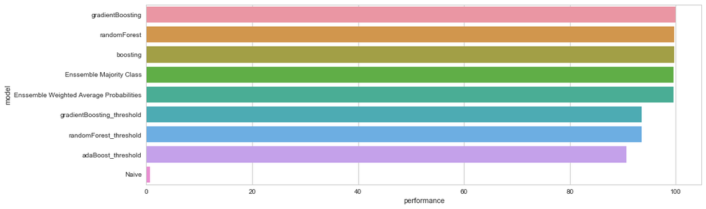

```python
plt.figure(figsize=(15,5))
sns.barplot(y="model", x="performance", data=res_df)
```